# Women in STEM

BF group 4

5/18/2020

# Our research

We are looking into Women in education and the workforce throughout the years, mainly in STEM (science, technology, engineering, and math) related fields.

Our group is interested in this topic for we are all females within a STEM-related major and wanted to know more about how it has changed and become more inclusive and what still needs to be improved. It has come a long way with more programs being added to help encourage girls to become more involved in STEM and make a career out of it. But there is still more to be done and the sooner its made aware to the public the sooner it can be changed for the better.

## Source of our datasets

women_bachelor_stem.csv https://www.nsf.gov/statistics/2018/nsb20181/report/sections/higher-education-in-science-and-engineering/undergraduate-education-enrollment-and-degrees-in-the-united-states?fbclid=IwAR3u37RvFzkKV71x4dYlMxageo5LIAWGUKSlMrU0pbIJkH__7JFXGpc2O00

Employee Diversity in tech - May 2018.csv https://docs.google.com/spreadsheets/d/1e5jevLJTK9Aayob2msk4Ss9qIMCqfris4m_m0kXO-7s/edit?fbclid=IwAR1hTJ9ZPiwaN0h6O0uStf9rCR0d1DFhTEBUx3yxQU3wGb8Zq5jz4XzVSt0#gid=65558231

Women in STEM Labor data.csv: https://www.dol.gov/agencies/wb/data/facts-over-time/women-in-the-labor-force?fbclid=IwAR1myw6ytyR83MC__0T-NebIDTVzCXVbJ1NnZZlW2BjHwl0TDNI5YbzEK6Y#womenstem

Women in Software Engineering stats - Sheet1.csv: https://github.com/alison985/women-in-tech-datasets/blob/master/datasets/company_coder_gender_stats/2016-03-18-women_in_software_engineering_stats.csv

female-labor-force-participation-OECD.csv: https://ourworldindata.org/female-labor-supply

# Summary Info

### Women in Software Engineering stats

The average of women engineers in this dataset is 20.7279443%, with the highest proportion of 100% in the companies Spitfire Athlete, Kabinet, HIPAA Risk Management, Tog+Porter. The lowest proportion of women engineers is 0%, in the companies Nextdoor, Shift, Guidebook, Annax, Fog Creek Software, Harvest, Collective IDea, Moontoast, StackMob, creativeLIVE, Topix, Massdrop, doxo, Checkout 51, FirstWatch Solutions, The Playforge, Circa, Kaon Interactive, Inc., appssavvy, Sifteo, Qstream, PolicyStat, Codurance, London, Goldbely, circl, Brooklyn, Webkite, Watsi, Zerocater, 1up talent. This information is important because I wanted to see which companies are more gender inclusive and which ones are less gender inclusive when it comes to hiring software engineers. This calculation also shows the mean percentage of female software engineers.

# Summary Tables & Charts

### Table One

| year | Women as Engineers(%) |
| --- | --- |
| 2013 | 12.89333 |
| 2014 | 10.54000 |
| 2015 | 11.58625 |
| 2016 | 13.83000 |
| 2017 | 17.28200 |

This table shows the percent of women engineers compared to the total number of engineers across different companies that have more than 100 total engineers to not include too many outliers. 2018 and 2019 are also excluded from this table because the dataset didn’t contain enough information on these years to provide adequate information. This table is included to show how many women are receiving jobs in the science and engineering field compared to the total number of people employed in the same sector at different tech companies. The table shows that there has been growth over the five-year time frame. With some staggering and a big jump at the end in 2017. Even though there has been some growth, the percentage of women is still very low, showing that there is still room for improvement.

### Chart 1

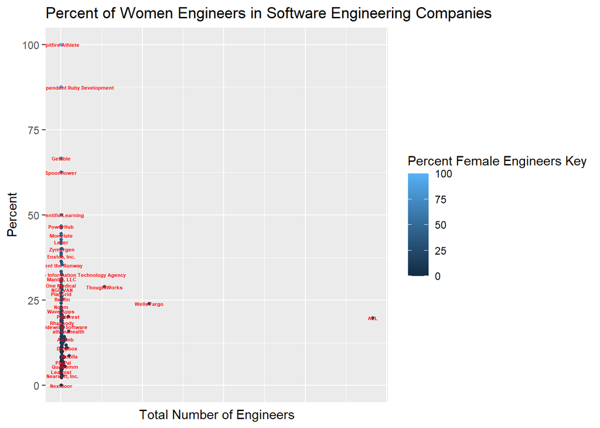

### Table Two

| Year | Graduated in Computer Science (%) |
| --- | --- |
| 2000 | 28 |
| 2001 | 27.6 |
| 2002 | 27.5 |
| 2003 | 27 |
| 2004 | 25.1 |
| 2005 | 22.3 |
| 2006 | 20.7 |
| 2007 | 18.6 |
| 2008 | 17.7 |
| 2009 | 17.9 |
| 2010 | 18.2 |
| 2011 | 17.7 |
| 2012 | 18.2 |
| 2013 | 17.9 |
| 2014 | 18.1 |
| 2015 | 18 |

This table displays information on the percent of graduates with a major in computer science who are female. This table is used to show how many female graduates are pursuing a career within the computer science industry which falls under the STEM spectrum. The table shows a downward trend in the percent of female graduates in computer science, by 10 percet. This could indicate that women are pursuing other STEM majors or the competition with the computer science major is rising to make it harder to be accepted into the major.

### Chart 2

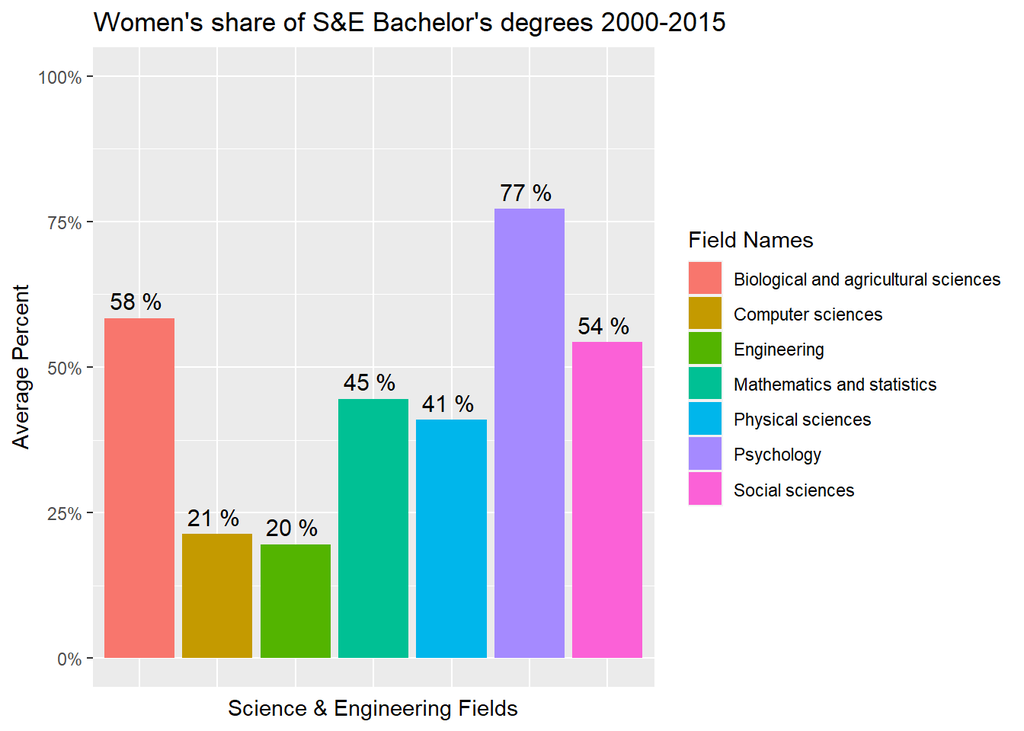

This bar chart shows an overview of women’s participation in education in STEM fields, and compares the averages of the Women’s share of bachelor’s degrees for science and engineering fields from 2000 - 2015. While the percentage of women in STEM in education and the workforce has been growing overall, there are still major differences between the individual fields, and some fields have seen very little growth. These statistics really speak to the fact that women are still underrepresented in some industries and fields inside STEM. On average, women have earned more than 50% of the bachelor’s degrees in Psychology, Biological/Agricultural sciences, and Social sciences; however, they are only earning an average of *21%* of Computer science degrees. This highlights the fact that there is still a huge gender gap in the CS field. This also shows up in the Engineering field, where women are only earning an average of *20%* of the degrees. Whether it’s because of a lingering cultural stigma of women in these fields, a lack of role models, or sexism in the workplace, not all STEM fields have been having the percentages of women in them grow over the past decade.

### Table Three

| Year | Women in Workforce | Women in STEM Occupations |
| --- | --- | --- |
| 1970 | 43.33920 | 7 |
| 1980 | 51.47568 | 14 |
| 1990 | 57.52723 | 23 |
| 2000 | 59.94196 | 25 |
| 2010 | 58.62167 | 26 |

Comparing the total percentage of women in the workforce to the percentage of women working within STEM occupations throughout the decades of 1970 to 2010. This table helps to explore how the trends of women in the workforce have changed. In this table it shows how women in the workforce have grown some, but the percentage of women in STEM occupations has grown a lot. In 40 years it went up almost 20 percent, eventhough that is a big jump it only adds up to a little over a quarter of the total STEM employees, which shows that there is still a gender gap within the field.

### Chart 3

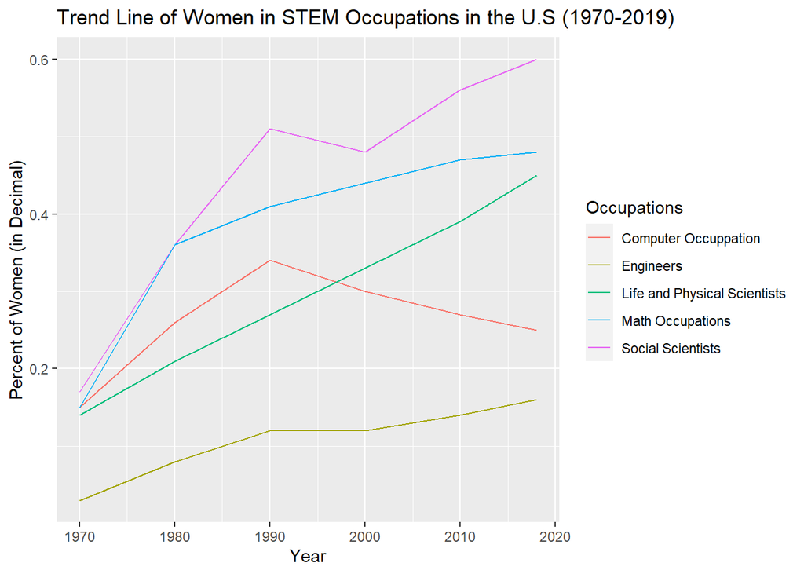

This trend line shows the percentages (in decimal) of women within different STEM occupations in the U.S from 1970-2019. Overall, most of the occupations are trending upward throughout the years. Computer occupations have been trending downward since 1990. Out of all them we can see the least participation in Engineering and the most in Social Sciences.